# Facies Classification

```r
# Clean the environment with the following command
rm(list = ls())
```

This is an [R Markdown](http://rmarkdown.rstudio.com) Notebook for the [Facies Classification Contest](https://github.com/seg/2016-ml-contest). In this notebook, I will try different classification methods that involve [decision trees](https://en.wikipedia.org/wiki/Decision_tree_learning) and [ensemble classifiers](https://en.wikipedia.org/wiki/Ensemble_learning).

This data is from the [2016 ML contest](https://github.com/seg/2016-ml-contest), with the focus for *Facies Classification*.

The provided data is a CSV file with well logs information from different wells. There are 5 well logs and 2 indicators:

- Gamma ray (GR)
- Resistivity (ILD_log10)
- Photoelectric effect (PE)
- Neutron-density porosity difference (DeltaPHI)
- Average neutron-density porosity (PHIND)
- Nonmarine/marine indicator (NM_M)
- Relative position (RELPOS)

The goal is to train a model able to classify 9 different types of rocks, as listed in the following table:

| Facies | Description | Label | Adjacent Facies |
| --- | --- | --- | --- |
| 1 | Nonmarine Sandstone | SS | 2 |
| 2 | Nonmarine coarse siltstone | CSiS | 1,3 |
| 3 | Nonmarine fine siltstone | FSiS | 2 |
| 4 | Marine siltstone and shale | SiSh | 5 |
| 5 | Mudstone | MS | 4,6 |
| 6 | Wackestone | WS | 5,7,8 |
| 7 | Dolomite | D | 6,8 |
| 8 | Packstone-grainstone | PS | 6,7,9 |
| 9 | Phylloid-algal bafflestone | BS | 7,8 |

So, let’s take a look at the data!

## Simple Modelling

```r
# Load .csv data to dataframe
data = read.csv("../Data/facies_vectors.csv")
head(data, 10)
```

|  | Facies | Formation | Well.Name | Depth | GR | ILD_log10 | DeltaPHI | PHIND | PE | NM_M | RELPOS |
| --- | --- | --- | --- | --- | --- | --- | --- | --- | --- | --- | --- |
| 1 | 3 | A1 SH | SHRIMPLIN | 2793.0 | 77.45 | 0.664 | 9.9 | 11.915 | 4.6 | 1 | 1.000 |
| 2 | 3 | A1 SH | SHRIMPLIN | 2793.5 | 78.26 | 0.661 | 14.2 | 12.565 | 4.1 | 1 | 0.979 |
| 3 | 3 | A1 SH | SHRIMPLIN | 2794.0 | 79.05 | 0.658 | 14.8 | 13.050 | 3.6 | 1 | 0.957 |
| 4 | 3 | A1 SH | SHRIMPLIN | 2794.5 | 86.10 | 0.655 | 13.9 | 13.115 | 3.5 | 1 | 0.936 |
| 5 | 3 | A1 SH | SHRIMPLIN | 2795.0 | 74.58 | 0.647 | 13.5 | 13.300 | 3.4 | 1 | 0.915 |
| 6 | 3 | A1 SH | SHRIMPLIN | 2795.5 | 73.97 | 0.636 | 14.0 | 13.385 | 3.6 | 1 | 0.894 |
| 7 | 3 | A1 SH | SHRIMPLIN | 2796.0 | 73.72 | 0.630 | 15.6 | 13.930 | 3.7 | 1 | 0.872 |
| 8 | 3 | A1 SH | SHRIMPLIN | 2796.5 | 75.65 | 0.625 | 16.5 | 13.920 | 3.5 | 1 | 0.830 |
| 9 | 3 | A1 SH | SHRIMPLIN | 2797.0 | 73.79 | 0.624 | 16.2 | 13.980 | 3.4 | 1 | 0.809 |
| 10 | 3 | A1 SH | SHRIMPLIN | 2797.5 | 76.89 | 0.615 | 16.9 | 14.220 | 3.5 | 1 | 0.787 |

Now I will create the list of features and facies names for future use:

```r
features = c('GR','ILD_log10','DeltaPHI','PHIND','PE','NM_M','RELPOS')
well_logs = c('GR','ILD_log10','DeltaPHI','PHIND','PE')
facies_names = c('SS', 'CSiS', 'FSiS', 'SiSh', 'MS', 'WS', 'D', 'PS', 'BS')
facies_colors = c("1" = '#F4D03F', "2" = '#F5B041', "3" = '#DC7633', "4" = '#6E2C00',
                  "5" = '#1B4F72', "6" = '#2E86C1', "7" = '#AED6F1', "8" = '#A569BD',
                  "9" = '#196F3D')
target = "Facies"
testWell = "SHANKLE"

source("Utils.R")
pright <- plotwelllogs(datap = data, wname = testWell, dz = "Depth", wlogs = well_logs,
             facies = "Facies", fcolor = facies_colors, fnames = facies_names)
```

[figure not shown]

```r
# Removing well "Recruit F9" from the data:
plotwelllogs(datap = data, wname = "Recruit F9", dz = "Depth", wlogs = well_logs,
             facies = "Facies", fcolor = facies_colors, fnames = facies_names)
```

[output not shown]

```r
dataf = data[data$Well.Name != 'Recruit F9',]
unique(dataf$Well.Name)
```

```
[1] SHRIMPLIN       ALEXANDER D     SHANKLE         LUKE G U        KIMZEY A        CROSS H CATTLE  NOLAN
[8] NEWBY           CHURCHMAN BIBLE
Levels: ALEXANDER D CHURCHMAN BIBLE CROSS H CATTLE KIMZEY A LUKE G U NEWBY NOLAN Recruit F9 SHANKLE SHRIMPLIN
```

Split data into train and test datasets by selecting the well *SHANKLE* as the blind well for validation:

```r
# For the xgboost package, target must be from 0 to num_class - 1
temp <- dataf
temp$Facies = temp$Facies - 1

# Separating the "blind well"
train = temp[temp$Well.Name != testWell, ]
test = temp[temp$Well.Name == testWell, ]
print(nrow(train))
```

```
[1] 3620
```

```r
print(nrow(test))
```

```
[1] 449
```

```r
print(nrow(dataf) - (nrow(train) + nrow(test)))
```

```
[1] 0
```

For the gradient boosting classifier, I will use the [xgboost](https://cran.r-project.org/web/packages/xgboost/index.html) package. Let’s load the libraries:

```r
library(xgboost, quietly = TRUE, verbose = FALSE)
library(Matrix, quietly = TRUE, verbose = FALSE)
library(archdata, quietly = TRUE, verbose = FALSE)
library(caret, quietly = TRUE, verbose = FALSE)
library(dplyr, quietly = TRUE, verbose = FALSE)
library(Ckmeans.1d.dp, quietly = TRUE, verbose = FALSE)
library(e1071, quietly = TRUE, verbose = FALSE)
library(ggplot2, quietly = TRUE, verbose = FALSE)
library(gridExtra, quietly = TRUE, verbose = FALSE)
library(ggpubr, quietly = TRUE, verbose = FALSE)
library(gplots, quietly = TRUE, verbose = FALSE)
library(reshape2, quietly = TRUE, verbose = FALSE)
library(tidyverse, quietly = TRUE, verbose = FALSE)
library(GGally, quietly = TRUE, verbose = FALSE)
library(signal, quietly = TRUE, verbose = FALSE)
```

To use the *xgboost package*, we need to “convert” the training and test datasets to **xgb.DMatrix**:

```r
# Converting datasets to xgb.DMatrix
dtrain = xgb.DMatrix(data.matrix(train[,features]),
                     label = data.matrix(train$Facies))
dtest = xgb.DMatrix(data.matrix(test[,features]),
                    label = data.matrix(test$Facies))

# Calculating number of classes in the data
numberOfClasses <- length(unique(dataf$Facies))

# Setting up parameters
param <- list(max_depth = 6,
              eta = 1,
              silent = 1,
              nthread = 2,
              #subsample = 0.5,
              objective = "multi:softmax",
              eval_metric = "merror",
              "num_class" = numberOfClasses)

# Defining training and evaluation sets
watchlist <- list(train = dtrain,
                  eval = dtest)

# Generating first model using Gradient Boosting Trees
model01 = xgb.train(param,
                    dtrain,
                    nrounds = 30,
                    watchlist)
```

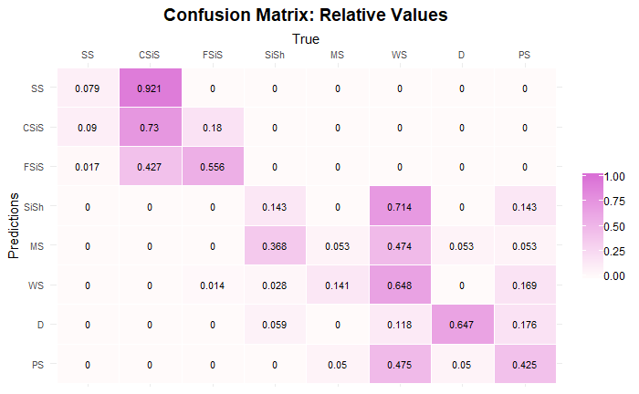

```r
# Computing prediction estimations for the test data
test_pred = predict(model01,
                    newdata = data.matrix(test[,features]))
train_pred = predict(model01,
                     newdata = data.matrix(train[,features]))

test$Predictions = test_pred

# confusion matrix of test set
xtab = createConfusionMatrix(test$Facies + 1,
                             test$Predictions + 1)
xtab = t(xtab)
rownames(xtab) <- facies_names[1:8]
colnames(xtab) <- facies_names[1:8]
plotConfusionMatrix(xtab, relScale = T)
```

```r
# Confucion matrix an statistical information
u <- union(test$Predictions + 1, test$Facies + 1)
t <- table(factor(test$Predictions + 1, u), factor(test$Facies + 1, u))

# Confucion matrix and statistical information
CM = confusionMatrix(t,
                     mode = "everything")
print(CM)
```

```
Confusion Matrix and Statistics


     3  2  1  5  8  6  4  7
  3 65 16  0  0  0  1  0  0
  2 50 65 82  0  0  0  0  0
  1  2  8  7  0  0  0  0  0
  5  0  0  0  1  2 10  0  0
  8  0  0  0  1 17 12  1  3
  6  0  0  0  9 19 46  5  2
  4  0  0  0  7  0  2  1  1
  7  0  0  0  1  2  0  0 11

Overall Statistics

               Accuracy : 0.4744
                 95% CI : (0.4274, 0.5217)
    No Information Rate : 0.2606
    P-Value [Acc > NIR] : < 2.2e-16

                  Kappa : 0.3589

 Mcnemar's Test P-Value : NA

Statistics by Class:

                     Class: 3 Class: 2 Class: 1 Class: 5 Class: 8 Class: 6 Class: 4 Class: 7
Sensitivity            0.5556   0.7303  0.07865 0.052632  0.42500   0.6479 0.142857  0.64706
Specificity            0.9488   0.6333  0.97222 0.972093  0.95844   0.9074 0.977376  0.99306
Pos Pred Value         0.7927   0.3299  0.41176 0.076923  0.50000   0.5679 0.090909  0.78571
Neg Pred Value         0.8583   0.9048  0.81019 0.958716  0.94458   0.9321 0.986301  0.98621
Precision              0.7927   0.3299  0.41176 0.076923  0.50000   0.5679 0.090909  0.78571
Recall                 0.5556   0.7303  0.07865 0.052632  0.42500   0.6479 0.142857  0.64706
F1                     0.6533   0.4545  0.13208 0.062500  0.45946   0.6053 0.111111  0.70968
Prevalence             0.2606   0.1982  0.19822 0.042316  0.08909   0.1581 0.015590  0.03786
Detection Rate         0.1448   0.1448  0.01559 0.002227  0.03786   0.1024 0.002227  0.02450
Detection Prevalence   0.1826   0.4388  0.03786 0.028953  0.07572   0.1804 0.024499  0.03118
Balanced Accuracy      0.7522   0.6818  0.52544 0.512362  0.69172   0.7776 0.560116  0.82006
```

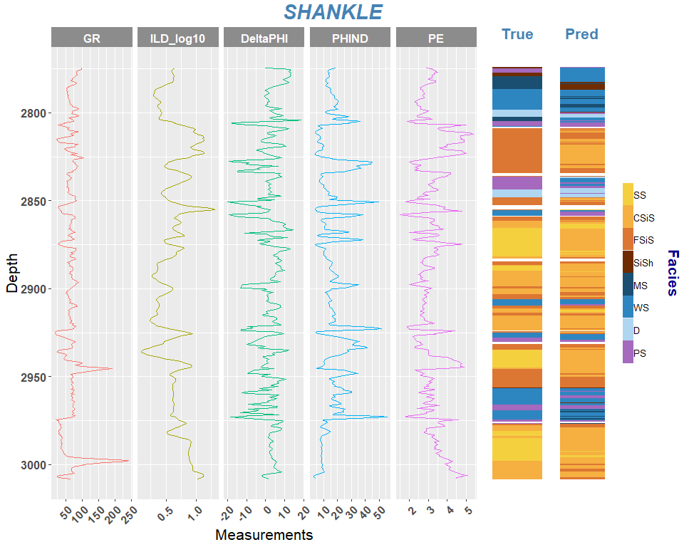

```r
dtemp = test
dtemp$Predictions <- dtemp$Predictions + 1
dtemp$Facies <- dtemp$Facies + 1
plotwellPred(datap = dtemp, wname = testWell, dz = "Depth", wlogs = well_logs,
             facies = "Facies", classy = "Predictions", fcolor = facies_colors,
             fnames = facies_names)
```

## Data Imputation

Now, let’s do some analysis of the data. First, let’s evaluate if there are any missing values on each well log and indicators:

```r
A = lapply(features, function(x) cat("Missing values of ", x, ": ",
                                     sum(is.na(dataf[, x])), "\n", sep = ""))
```

```
Missing values of GR: 0
Missing values of ILD_log10: 0
Missing values of DeltaPHI: 0
Missing values of PHIND: 0
Missing values of PE: 905
Missing values of NM_M: 0
Missing values of RELPOS: 0
```

Okay, there are 905 missing values for “*PE*”. For now, let’s replace the missing data simply by the “PE” column average:

```r
dataf[is.na(dataf[,"PE"]), "PE"] <- mean(dataf[,"PE"], na.rm = TRUE)

cat("Missing values of PE:", sum(is.na(dataf[, "PE"])))
```

```
Missing values of PE: 0
```

Now, let’s check all the well logs and facies classification for all the wells. The function *plotwelllogs* can be loaded from the file *Utils.R*:

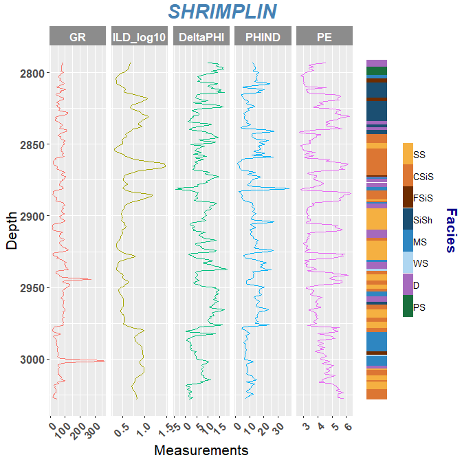

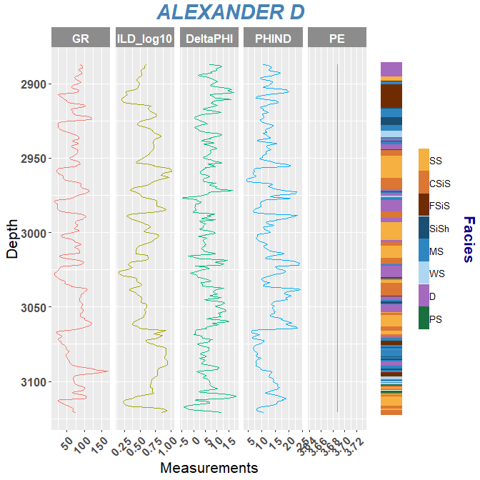

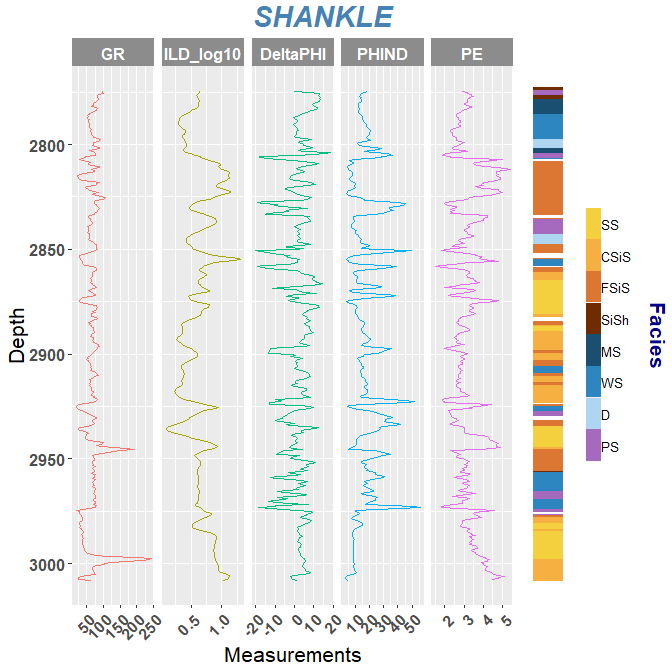

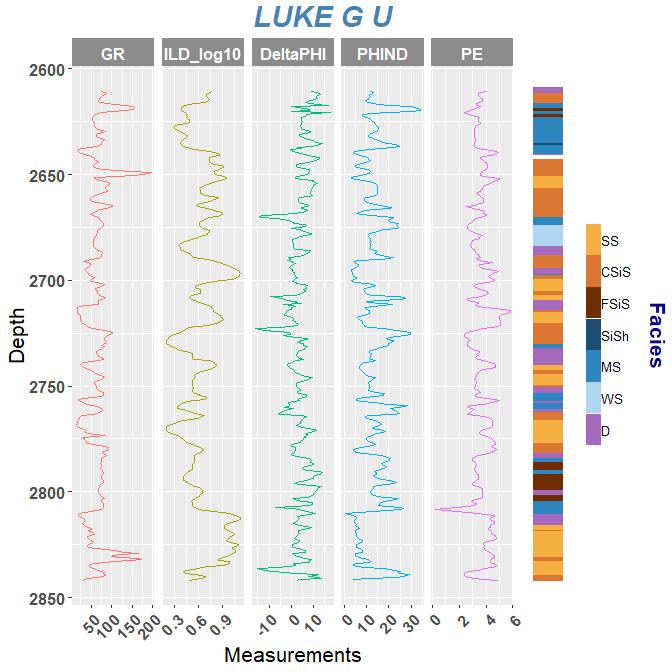

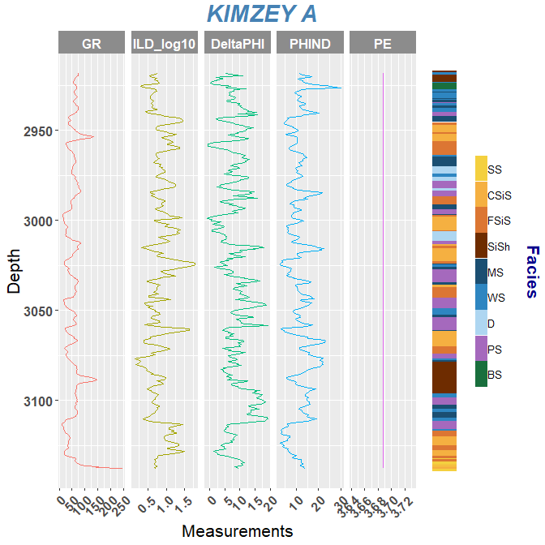

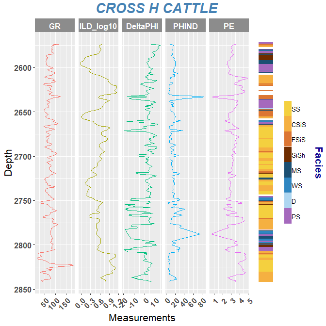

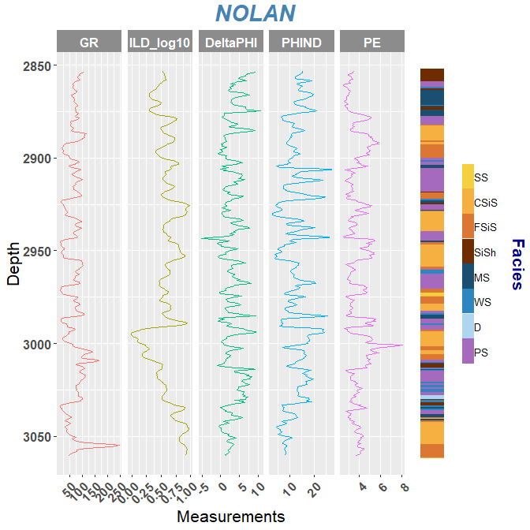

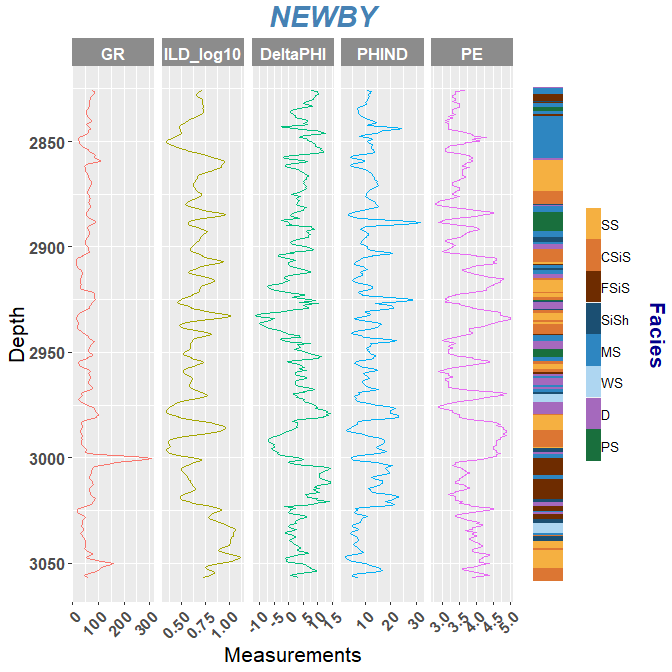

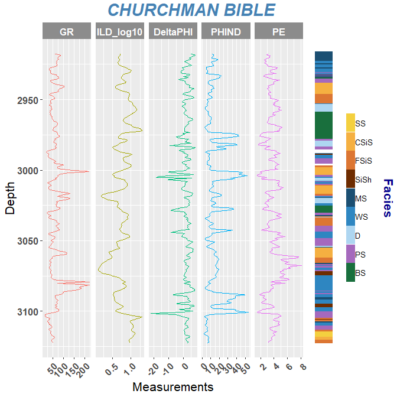

```r
wellname = unique(dataf$Well.Name)
for (ii in wellname){
  plotwelllogs(datap = dataf, wname = ii, dz = "Depth", wlogs = well_logs,
               facies = "Facies", fcolor = facies_colors, fnames = facies_names)
}
```

```r
# This function is just to save the legend in a variable to use later
pright <- getLegend(data, "CHURCHMAN BIBLE", "Depth", well_logs, "Facies",
                    facies_colors, facies_names)
```

### Data imputation using regression models

The **PE** for the wells *Alexander D* and *Kimzey A* are, actually, missing. Earlier I replaced the missing values by the average of the whole dataset, but it shows to be a poor solution. Instead, I’ll try now to replace the missing values by a **linear regression** prediction over the other well logs available. For that, we remove the “damaged” wells from the data, train a linear regression model, and do the predictions on the desired wells.

```r
# Se3lecting list of "good" and "damaged" wells
dwells = c("ALEXANDER D", "KIMZEY A") # "Damaged" wells
gwells = setdiff(wellname, dwells)    # Good wells
gwells = setdiff(gwells, testWell)    # Good wells

# Creating linear model and making predictions
lmModel <- lm(PE ~ GR + ILD_log10 + DeltaPHI + PHIND,
              data = dataf[dataf$Well.Name %in% c(gwells), ])
```

Let’s check the solution over the test well:

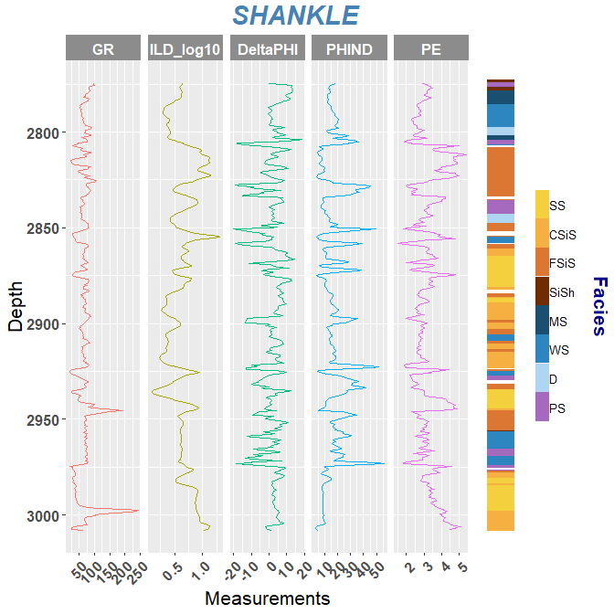

```r
pred = predict.lm(lmModel, dataf[dataf$Well.Name %in% c(testWell), ])
testlm = dataf[dataf$Well.Name %in% testWell, ]
testlm[ , "PE"] <- pred

plotwelllogs(datap = dataf, wname = testWell, dz = "Depth", wlogs = well_logs,
               facies = "Facies", fcolor = facies_colors, fnames = facies_names)
```

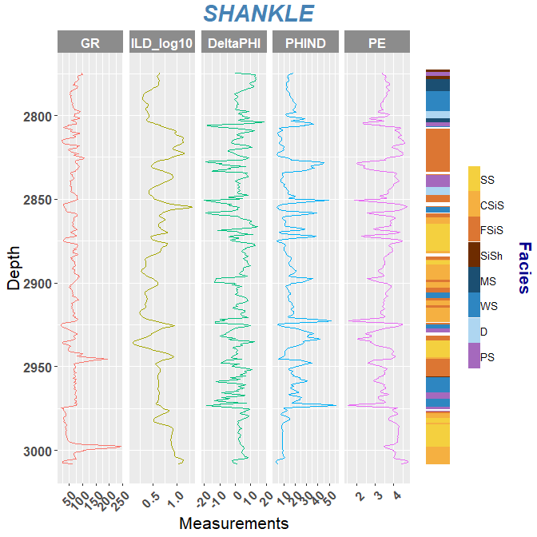

```r
plotwelllogs(datap = testlm, wname = testWell, dz = "Depth", wlogs = well_logs,
               facies = "Facies", fcolor = facies_colors, fnames = facies_names)
```

Retrain the linear regression with all the good wells:

```r
# Se3lecting list of "good" and "damaged" wells
dwells = c("ALEXANDER D", "KIMZEY A") # "Damaged" wells
gwells = setdiff(wellname, dwells)    # Good wells

# Creating linear model and making predictions
lmModel <- lm(PE ~ GR + ILD_log10 + DeltaPHI + PHIND,
              data = dataf[dataf$Well.Name %in% c(gwells), ])
```

Predicting the **PE** for the wells with missing values:

```r
predictions = predict.lm(lmModel, dataf[dataf$Well.Name %in% c(dwells), ])
datalm <- dataf
datalm[which(datalm$Well.Name %in% c(dwells)), "PE"] <- predictions
cat("Missing values of PE:", sum(is.na(datalm[, "PE"])))
```

```
Missing values of PE: 0
```

Let’s make the plot for both wells:

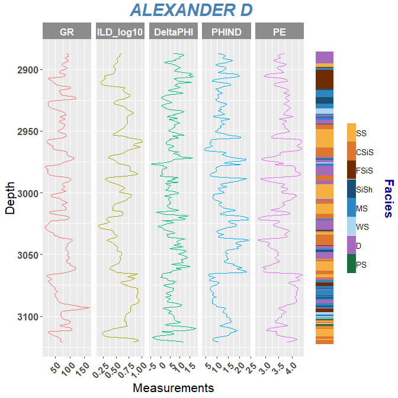

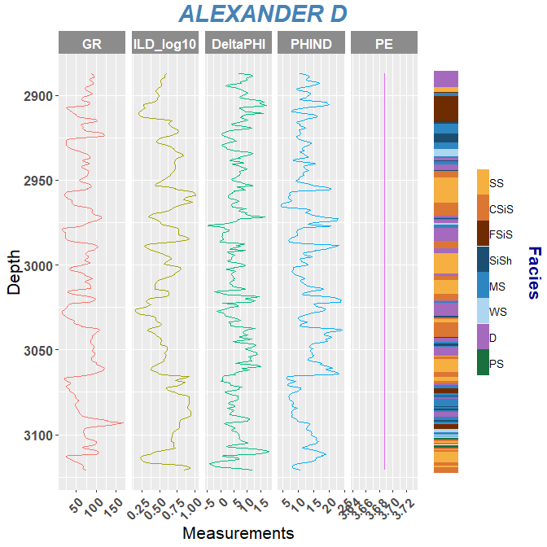

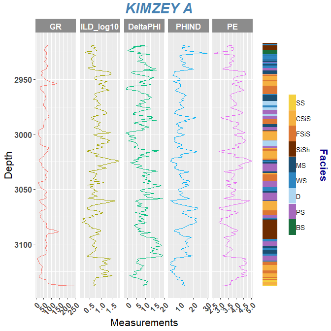

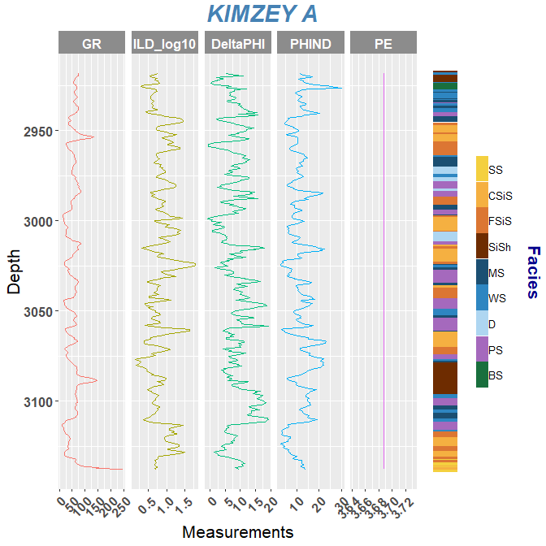

```r
for (ii in dwells){
  plotwelllogs(datap = datalm, wname = ii, dz = "Depth", wlogs = well_logs,
               facies = "Facies", fcolor = facies_colors, fnames = facies_names)
  plotwelllogs(datap = dataf, wname = ii, dz = "Depth", wlogs = well_logs,
               facies = "Facies", fcolor = facies_colors, fnames = facies_names)
}
```

Okay, good. Let’s recreate the *gradient boosting model* with this new dataset. First, after the data imputation, split the data into test and train sets:

```r
# For the xgboost package, target must be from 0 to num_class - 1
temp <- datalm
temp$Facies = temp$Facies - 1

# Splitting data
trainlm = temp[temp$Well.Name != testWell, ]
testlm = temp[temp$Well.Name == testWell, ]
```

Run the *xgboost*:

```r
# Converting datasets to xgb.DMatrix
dtrainlm = xgb.DMatrix(data.matrix(trainlm[,features]),
                       label = data.matrix(trainlm$Facies))
dtestlm = xgb.DMatrix(data.matrix(testlm[,features]),
                      label = data.matrix(testlm$Facies))

# Calculating number of classes in the data
numberOfClasses <- length(unique(dataf$Facies))

# Setting up parameters
param <- list(max_depth = 6,
              eta = .5,
              silent = 1,
              nthread = 2,
              #subsample = 0.5,
              objective = "multi:softmax",
              eval_metric = "merror",
              "num_class" = numberOfClasses)

# Defining training and evaluation sets
watchlist <- list(train = dtrainlm,
                  eval = dtestlm)

# Generating first model using Gradient Boosting Trees
modellm = xgb.train(param,
                    dtrainlm,
                    nrounds = 75,
                    watchlist)
```

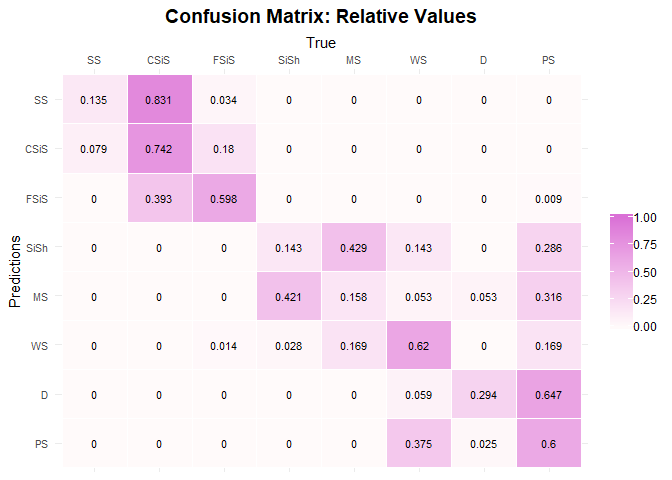

```r
# Computing prediction estimations for the test data
testlm_pred = predict(modellm,
                      newdata = data.matrix(testlm[,features]))
trainlm_pred = predict(modellm,
                       newdata = data.matrix(trainlm[,features]))

testlm$Predictions = testlm_pred

# confusion matrix of test set
xtablm = createConfusionMatrix(testlm$Facies + 1,
                               testlm$Predictions + 1)
xtablm = t(xtablm)
rownames(xtablm) <- facies_names[1:8]
colnames(xtablm) <- facies_names[1:8]
plotConfusionMatrix(xtablm, relScale = T)
```

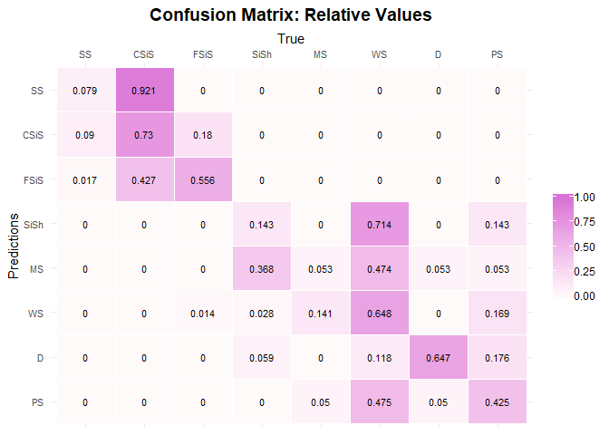

```r
plotConfusionMatrix(xtab, relScale = T)
```

```r
# Confucion matrix and statistical information
u <- union(testlm$Predictions + 1, testlm$Facies + 1)
t <- table(factor(testlm$Predictions + 1, u), factor(testlm$Facies + 1, u))
CMlm = confusionMatrix(t,
                     mode = "everything")
cat("Accuracy with imputed data:", CMlm$overall[1], '\n')
```

```
Accuracy with imputed data: 0.5011136
```

```r
cat("Previous accuracy:", CM$overall[1], '\n')
```

```
Previous accuracy: 0.4743875
```

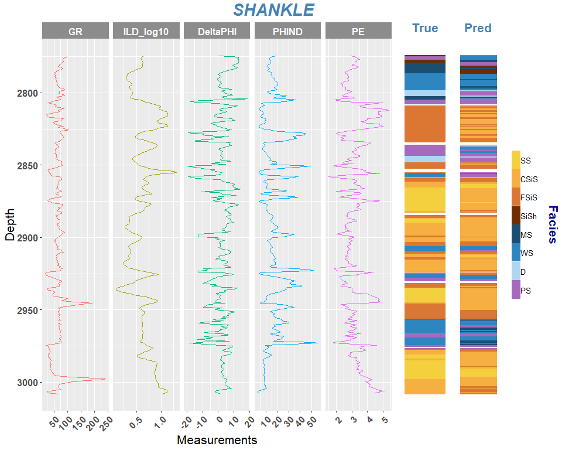

```r
dtemp = testlm
dtemp$Predictions <- dtemp$Predictions + 1
dtemp$Facies <- dtemp$Facies + 1
plotwellPred(datap = dtemp, wname = testWell, dz = "Depth", wlogs = well_logs,
             facies = "Facies", classy = "Predictions", fcolor = facies_colors,
             fnames = facies_names)
```

The data imputation of the missing *PE* logs increased the process accuracy, but it is still too low. We need to work with [feature augement](https://en.wikipedia.org/wiki/Augmented_matrix). In others words, we need to use our data to create new features, by using some combination rule.

## Feature Engeneering

Let’s do some analysis of the data and do a [pairs plot](https://en.wikipedia.org/wiki/Scatter_plot):

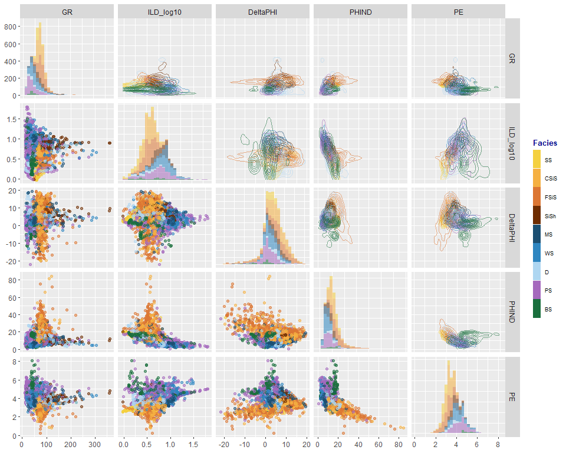

```r
pm = ggpairs(datalm,
             columns = match(c(well_logs), colnames(datalm)),
             aes(colour = factor(Facies),
                 alpha = 0.3),
             diag = list(continuous = "barDiag"),
             upper = list(continuous = "density"),
             lower = list(continuous = "points", combo = "dot_no_facet"),
             legend = pright)

# Change color manually.
# Loop through each plot changing relevant scales
for(i in 1:pm$nrow) {
  for(j in 1:pm$ncol){
    pm[i,j] <- pm[i,j] +
        scale_fill_manual(values=c(facies_colors)) +
        scale_color_manual(values=c(facies_colors))
  }
}

pm
```

### Polar coordinates

We can see some “circular” behavior of the pairs plot and data classification (facies). It is more clear when analyzing the density plots. So, to see if we can improve the facies classification, let’s convert the “cardinal” coordinates of the pairs to polar coordinates, using the function *cart2polwells* from the support file *Utils.R*.

```r
data_polar = cart2polwells(datalm,well_logs)
nofeatures = c("Facies","Formation", "Well.Name", "Depth")
features_pol = colnames(data_polar)
features_pol = features_pol[! features_pol %in% nofeatures]
```

Now, with the new coordinates, recreate the test and validation sets and then train the model:

```r
# For the xgboost package, target must be from 0 to num_class - 1
temp <- data_polar
temp$Facies = temp$Facies - 1

# Splitting data
trainpol = temp[temp$Well.Name != testWell, ]
testpol = temp[temp$Well.Name == testWell, ]

# Converting datasets to xgb.DMatrix
dtrainpol = xgb.DMatrix(data.matrix(trainpol[,features_pol]),
                        label = data.matrix(trainpol$Facies))
dtestpol = xgb.DMatrix(data.matrix(testpol[,features_pol]),
                       label = data.matrix(testpol$Facies))

mdepth = round(length(features_pol)/2)

# Setting up parameters
param <- list(max_depth = 5,
              eta = .3,
              silent = 1,
              nthread = 10,
              objective = "multi:softmax",
              eval_metric = "merror",
              "num_class" = numberOfClasses)

# Defining training and evaluation sets
watchlist <- list(train = dtrainpol,
                  eval = dtestpol)

# Generating first model using Gradient Boosting Trees
modelpol = xgb.train(param,
                     dtrainpol,
                     nrounds = 47,
                     watchlist)
```

Plot confusion matrix and evaluate accuracy:

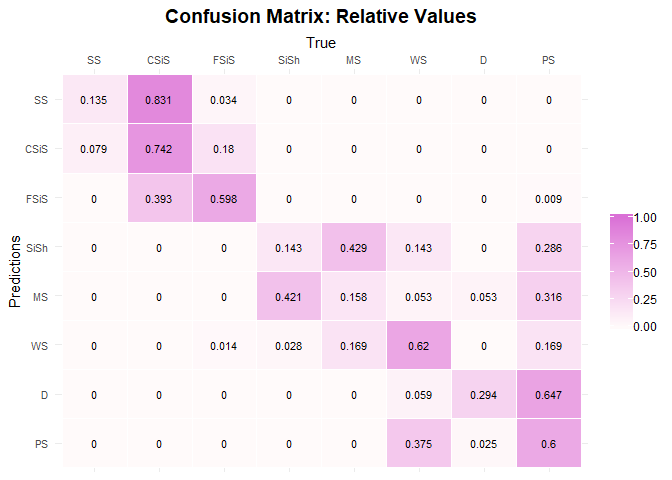

```r
# Computing prediction estimations for the test data
testpol_pred = predict(modelpol,
                       newdata = data.matrix(testpol[,features_pol]))
trainpol_pred = predict(modelpol,
                        newdata = data.matrix(trainpol[,features_pol]))

testpol$Predictions = testpol_pred

# confusion matrix of test set
xtabpol = createConfusionMatrix(testpol$Facies + 1,
                                testpol$Predictions + 1)
xtabpol = t(xtabpol)
rownames(xtabpol) <- facies_names[1:8]
colnames(xtabpol) <- facies_names
plotConfusionMatrix(xtablm, relScale = T)
```

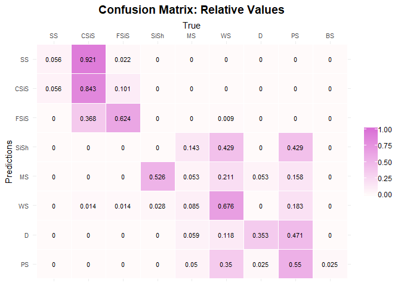

```r
plotConfusionMatrix(xtabpol, relScale = T)
```

```r
# Confucion matrix an statistical information
u <- union(testpol$Predictions + 1, testpol$Facies + 1)
t <- table(factor(testpol$Predictions + 1, u), factor(testpol$Facies + 1, u))

# Confucion matrix and statistical information
CMpol = confusionMatrix(t,
                        mode = "everything")
cat("Accuracy (polar):   ",CMpol$overall[1], "\n")
```

```
Accuracy (polar):    0.5122494
```

```r
cat("Accuracy (LM):      ",CMlm$overall[1], "\n")
```

```
Accuracy (LM):       0.5011136
```

```r
cat("Accuracy (original):",CM$overall[1], "\n")
```

```
Accuracy (original): 0.4743875
```

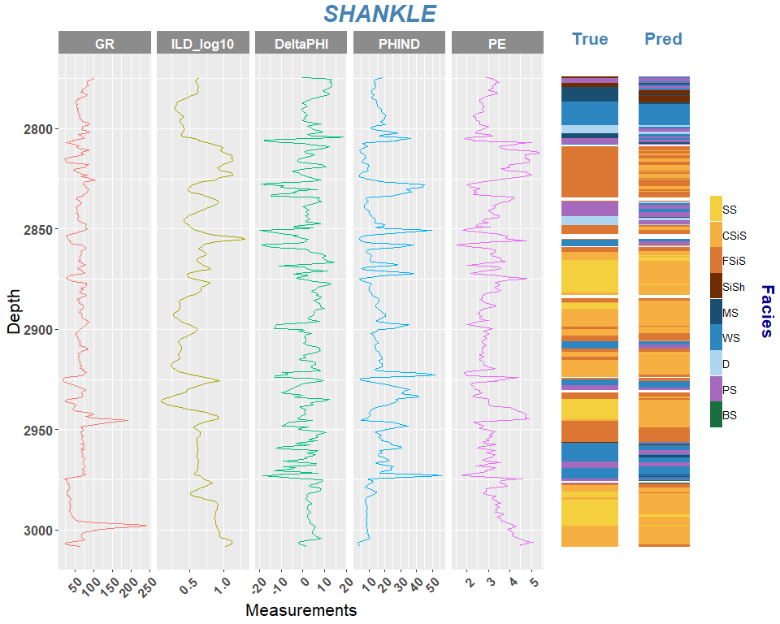

```r
dtemp = testpol
dtemp$Predictions <- dtemp$Predictions + 1
dtemp$Facies <- dtemp$Facies + 1
plotwellPred(datap = dtemp, wname = testWell, dz = "Depth", wlogs = well_logs,
             facies = "Facies", classy = "Predictions", fcolor = facies_colors,
             fnames = facies_names)
```

### Gradient of the features

With the data imputation and the polar coordinates changes, we could increase the precision of the model by around 3.5 percentual points. Now, others competitors used the feature gradient as new features. Let’s do the same by using the function *features_gradient* from the file *Utils.R*:

```r
data_grad = features_gradient(data_polar, features_pol, wellname)
features_grad = colnames(data_grad)
features_grad = features_grad[! features_grad %in% nofeatures]
```

Now, new model training:

```r
# For the xgboost package, target must be from 0 to num_class - 1
temp <- data_grad
temp$Facies = temp$Facies - 1

# Splitting data
traingrad = temp[temp$Well.Name != testWell, ]
testgrad = temp[temp$Well.Name == testWell, ]

# Converting datasets to xgb.DMatrix
dtraingrad = xgb.DMatrix(data.matrix(traingrad[,features_grad]),
                         label = data.matrix(traingrad$Facies))
dtestgrad = xgb.DMatrix(data.matrix(testgrad[,features_grad]),
                        label = data.matrix(testgrad$Facies))
mdepth = round(length(features_grad)/2)

# Setting up parameters
param <- list(max_depth = 7,
              eta = .3,
              silent = 1,
              nthread = 2,
              objective = "multi:softmax",
              eval_metric = "merror",
              "num_class" = numberOfClasses)

# Defining training and evaluation sets
watchlist <- list(train = dtraingrad,
                  eval = dtestgrad)

# Generating first model using Gradient Boosting Trees
modelgrad = xgb.train(param,
                      dtraingrad,
                      nrounds = 11,
                      watchlist)
```

```r
# Computing prediction estimations for the test data
testgrad_pred = predict(modelgrad,
                        newdata = data.matrix(testgrad[,features_grad]))
traingrad_pred = predict(modelgrad,
                         newdata = data.matrix(traingrad[,features_grad]))

testgrad$Predictions = testgrad_pred

# confusion matrix of test set
xtabgrad = createConfusionMatrix(testgrad$Facies + 1,
                                 testgrad$Predictions + 1)
xtabgrad = t(xtabgrad)
rownames(xtabgrad) <- facies_names[1:8]
colnames(xtabgrad) <- facies_names[1:8]
plotConfusionMatrix(xtabgrad, relScale = T)
```

[output not shown]

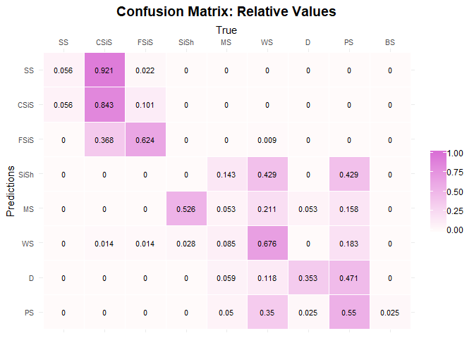

```r
plotConfusionMatrix(xtabpol, relScale = T)
```

```r
# Confucion matrix and statistical information
u <- union(testgrad$Predictions + 1, testgrad$Facies + 1)
t <- table(factor(testgrad$Predictions + 1, u), factor(testgrad$Facies + 1, u))
CMgrad = confusionMatrix(t,
                         mode = "everything")
cat("Accuracy (gradient):",CMgrad$overall[1], "\n")
```

```
Accuracy (gradient): 0.5545657
```

```r
cat("Accuracy (polar):   ",CMpol$overall[1], "\n")
```

```
Accuracy (polar):    0.5122494
```

```r
cat("Accuracy (LM):      ",CMlm$overall[1], "\n")
```

```
Accuracy (LM):       0.5011136
```

```r
cat("Accuracy (original):",CM$overall[1], "\n")
```

```
Accuracy (original): 0.4743875
```

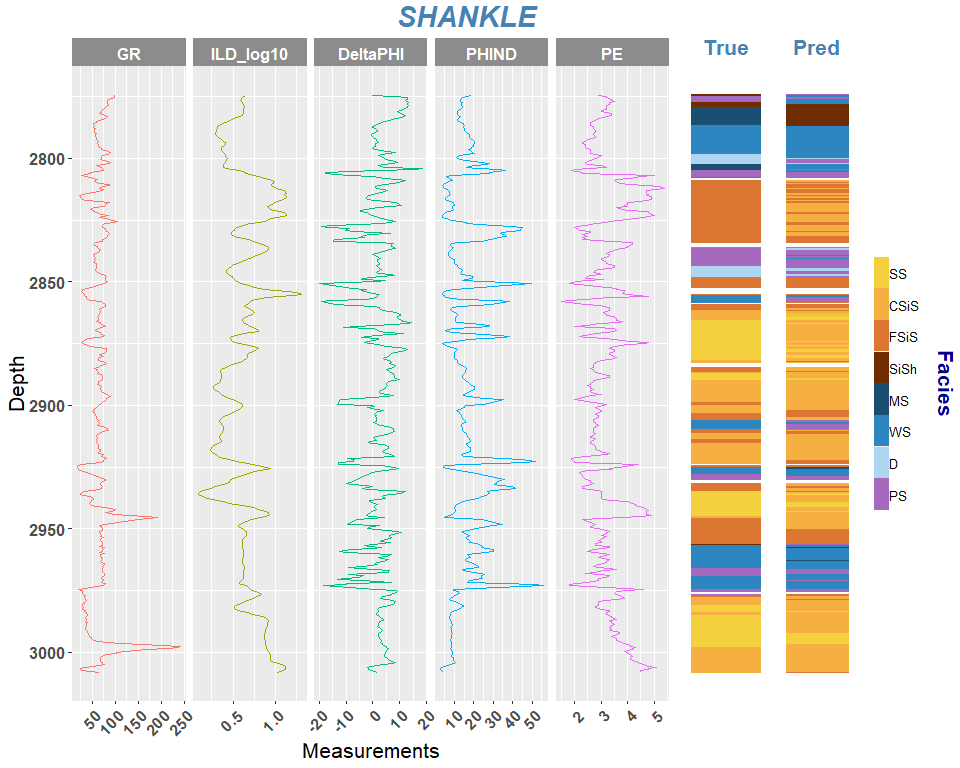

```r
dtemp = testgrad
dtemp$Predictions <- dtemp$Predictions + 1
dtemp$Facies <- dtemp$Facies + 1
plotwellPred(datap = dtemp, wname = testWell, dz = "Depth", wlogs = well_logs,
             facies = "Facies", classy = "Predictions", fcolor = facies_colors,
             fnames = facies_names)
```

Creating the gradient over all the features showed to be an excellent decision, and the accuracy is increased. To deliver the final facies classification predictions, we assume that isolated facies inside a “block” is something rare (not impossible, though). So, we will “fix” is by applying a median filter.

## Correcting the predictions

```r
testgrad2 = testgrad
testgrad2$Classy = testgrad_pred
for (w in wellname){
  testgrad2[which(testgrad2$Well.Name %in% w), "Classy"] =
    runmed(testgrad2[which(testgrad2$Well.Name %in% w), "Classy"],
           k = 5, endrule = c("keep"))
}

u = union(testgrad2$Facies, testgrad2$Predictions)

# confusion matrix of test set
xtabgrad2 = createConfusionMatrix(testgrad2$Facies + 1,
                                  testgrad2$Classy + 1)
xtabgrad2 = t(xtabgrad2)
rownames(xtabgrad2) <- facies_names[1:8]
colnames(xtabgrad2) <- facies_names[1:8]
plotConfusionMatrix(xtabgrad, relScale = T)
```

[output not shown]

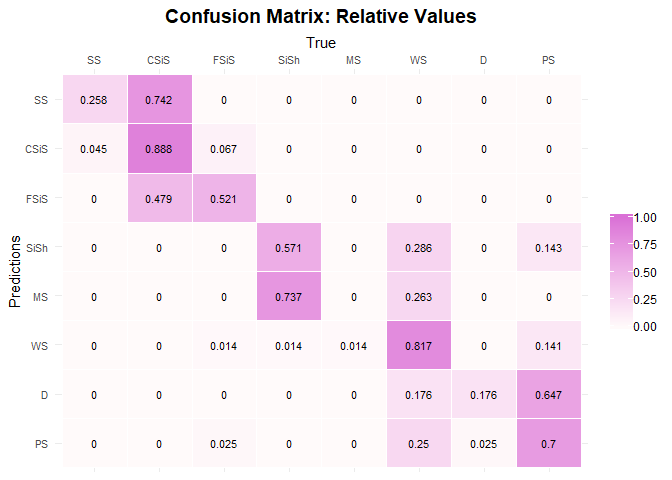

```r
plotConfusionMatrix(xtabgrad2, relScale = T)
```

```r
u <- union(testgrad2$Classy + 1, testgrad2$Facies + 1)
t <- table(factor(testgrad2$Classy + 1, u), factor(testgrad2$Facies + 1, u))

# Confucion matrix and statistical information
CMgrad2 = confusionMatrix(t,
                          mode = "everything")
cat("Accuracy (gradient):",CMgrad2$overall[1], "\n")
```

```
Accuracy (gradient): 0.5701559
```

Plotting the final predictions:

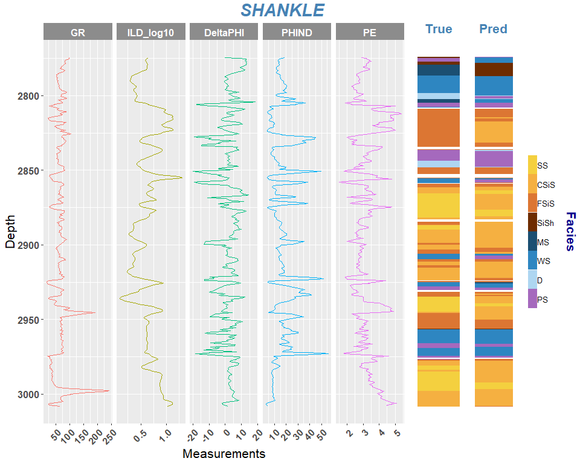

```r
dtemp = testgrad2
dtemp$Classy <- dtemp$Classy + 1
dtemp$Facies <- dtemp$Facies + 1
plotwellPred(datap = dtemp, wname = testWell, dz = "Depth", wlogs = well_logs,
             facies = "Facies", classy = "Classy", fcolor = facies_colors,
             fnames = facies_names)
```

Chacking features importance:

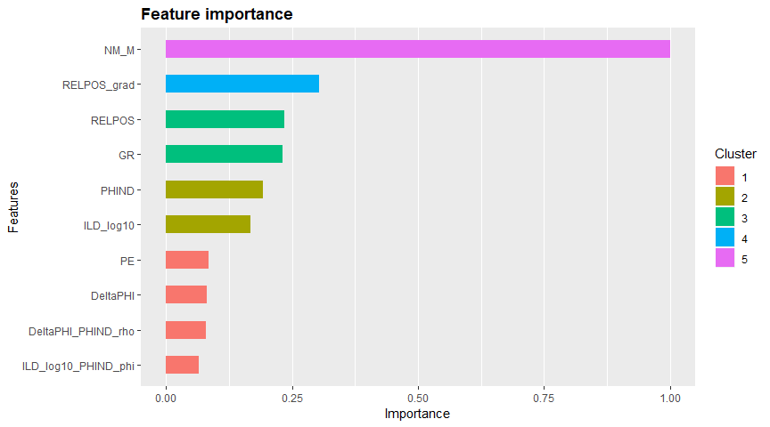

```r
importance <- xgb.importance(feature_names = features_grad, model = modelgrad)
xgb.ggplot.importance(importance, top_n = 10, measure = "Gain", rel_to_first = T, n_clusters = 5)
```

## Clustering

Now, let’s try to run a clustering algorithm to create new features. Clustering algorithms, for this purpose, are considered “unsupervised learning”, as they don’t require to be trained with the correct answer. Those algorithms just find similarities between the data intupts and separate them in clusters.

```r
set.seed(101)

# Features not used for the clustering
no_clust = c("RELPOS", "NM_M", "RELPOS_grad", "NM_M_grad")
features_cluster = features_grad[! features_grad %in% no_clust]

# Replacing missing values by 0
for (x in features_cluster) {
  data_grad[is.na(data_grad[,x]), x] <- 0
}

#features_cluster = features_grad[features_grad != no_clust]
Cluster = kmeans(as.matrix(data_grad[,features_cluster]), 6)
data_grad$cluster = as.factor(Cluster$cluster)
head(data_grad)
```

|  | Facies | Formation | Well.Name | Depth | GR | ILD_log10 | DeltaPHI | PHIND | PE | NM_M | RELPOS | GR_ILD_log10_rho | GR_ILD_log10_phi | GR_DeltaPHI_rho | GR_DeltaPHI_phi | GR_PHIND_rho | GR_PHIND_phi | GR_PE_rho | GR_PE_phi | ILD_log10_DeltaPHI_rho | ILD_log10_DeltaPHI_phi | ILD_log10_PHIND_rho | ILD_log10_PHIND_phi | ILD_log10_PE_rho | ILD_log10_PE_phi | DeltaPHI_PHIND_rho | DeltaPHI_PHIND_phi | DeltaPHI_PE_rho | DeltaPHI_PE_phi | … |
| --- | --- | --- | --- | --- | --- | --- | --- | --- | --- | --- | --- | --- | --- | --- | --- | --- | --- | --- | --- | --- | --- | --- | --- | --- | --- | --- | --- | --- | --- | --- |
| 1 | 3 | A1 SH | SHRIMPLIN | 2793.0 | 77.45 | 0.664 | 9.9 | 11.915 | 4.6 | 1 | 1.000 | 12.091756 | 2.709224e-04 | 13.26500 | 0.4237504 | 12.161001 | -0.106765903 | 12.124762 | 0.073803009 | 5.454331 | 1.570196 | 1.29591911 | -1.568268 | 0.8940378 | 1.567132 | 5.606167 | -0.233268584 | 5.527116 | 0.16246756 | … |
| 2 | 3 | A1 SH | SHRIMPLIN | 2793.5 | 78.26 | 0.661 | 14.2 | 12.565 | 4.1 | 1 | 0.979 | 12.901755 | 2.138678e-05 | 16.17412 | 0.6473598 | 12.917914 | -0.050022350 | 12.907771 | 0.030531451 | 9.754330 | 1.570768 | 0.64591503 | -1.570369 | 0.3940318 | 1.570096 | 9.775692 | -0.066121749 | 9.762285 | 0.04037362 | … |
| 3 | 3 | A1 SH | SHRIMPLIN | 2794.0 | 79.05 | 0.658 | 14.8 | 13.050 | 3.6 | 1 | 0.957 | 13.691756 | -1.989572e-04 | 17.16614 | 0.6474863 | 13.692701 | -0.011752150 | 13.692166 | -0.007739412 | 10.354330 | -1.570533 | 0.16093802 | 1.553869 | 0.1060033 | 1.545095 | 10.355580 | -0.015539587 | 10.354872 | -0.01023384 | … |
| 4 | 3 | A1 SH | SHRIMPLIN | 2794.5 | 86.10 | 0.655 | 13.9 | 13.115 | 3.5 | 1 | 0.936 | 20.741756 | -2.759686e-04 | 22.79484 | 0.4276762 | 20.741977 | -0.004624212 | 20.742778 | -0.009929800 | 9.454332 | -1.570191 | 0.09608562 | 1.511188 | 0.2060478 | 1.543012 | 9.454817 | -0.010144735 | 9.456573 | -0.02178215 | … |
| 5 | 3 | A1 SH | SHRIMPLIN | 2795.0 | 74.58 | 0.647 | 13.5 | 13.300 | 3.4 | 1 | 0.915 | 9.221766 | -1.488227e-03 | 12.92369 | 0.7762375 | 9.222186 | 0.009660011 | 9.226830 | -0.033166792 | 9.054340 | -1.569281 | 0.09013597 | -1.417942 | 0.3062759 | 1.525972 | 9.054768 | 0.009838625 | 9.059498 | -0.03377962 | … |
| 6 | 3 | A1 SH | SHRIMPLIN | 2795.5 | 73.97 | 0.636 | 14.0 | 13.385 | 3.6 | 1 | 0.894 | 8.611791 | -2.870960e-03 | 12.86264 | 0.8372382 | 8.613515 | 0.020212061 | 8.612407 | -0.012304448 | 9.554362 | -1.568209 | 0.17583196 | -1.429717 | 0.1088143 | 1.341581 | 9.555916 | 0.018218522 | 9.554918 | -0.01109067 | … |

Training the classifier:

```r
# For the xgboost package, target must be from 0 to num_class - 1
temp <- data_grad
temp$Facies = temp$Facies - 1

# Splitting data
trainclust = temp[temp$Well.Name != testWell, ]
testclust = temp[temp$Well.Name == testWell, ]

# New set of features
features_clust = c(features_grad,"cluster")

# Converting datasets to xgb.DMatrix
dtrainclust = xgb.DMatrix(data.matrix(trainclust[,features_clust]),
                          label = data.matrix(trainclust$Facies))
dtestclust = xgb.DMatrix(data.matrix(testclust[,features_clust]),
                         label = data.matrix(testclust$Facies))
mdepth = round(length(features_clust)/2)

# Setting up parameters
param <- list(max_depth = 8,
              eta = .3,
              silent = 1,
              nthread = 2,
              objective = "multi:softmax",
              eval_metric = "merror",
              "num_class" = numberOfClasses)

# Defining training and evaluation sets
watchlist <- list(train = dtrainclust,
                  eval = dtestclust)

# Generating first model using Gradient Boosting Trees
modelclust = xgb.train(param,
                       dtrainclust,
                       nrounds = 27,
                       watchlist)
```

```r
# Computing prediction estimations for the test data
testclust_pred = predict(modelclust,
                         newdata = data.matrix(testclust[,features_clust]))
trainclust_pred = predict(modelclust,
                          newdata = data.matrix(trainclust[,features_clust]))

testclust$Predictions = testclust_pred

# confusion matrix of test set
xtabclust = createConfusionMatrix(testclust$Facies + 1,
                                  testclust$Predictions + 1)
xtabclust = t(xtabclust)
rownames(xtabgrad) <- facies_names[1:8]
colnames(xtabgrad) <- facies_names[1:8]
plotConfusionMatrix(xtabgrad, relScale = T)
```

[output not shown]

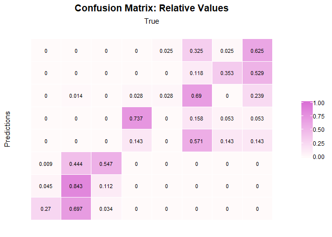

```r
plotConfusionMatrix(xtabclust, relScale = T)
```

```r
# Confucion matrix and statistical information
u <- union(testclust$Predictions + 1, testclust$Facies + 1)
t <- table(factor(testclust$Predictions + 1, u), factor(testclust$Facies + 1, u))
CMclust = confusionMatrix(t,
                          mode = "everything")
cat("Accuracy (cluster): ",CMclust$overall[1], "\n")
```

```
Accuracy (cluster):  0.5434298
```

```r
cat("Accuracy (gradient):",CMgrad2$overall[1], "\n")
```

```
Accuracy (gradient): 0.5701559
```

```r
cat("Accuracy (polar):   ",CMpol$overall[1], "\n")
```

```
Accuracy (polar):    0.5122494
```

```r
cat("Accuracy (LM):      ",CMlm$overall[1], "\n")
```

```
Accuracy (LM):       0.5011136
```

```r
cat("Accuracy (original):",CM$overall[1], "\n")
```

```
Accuracy (original): 0.4743875
```

```r
dtemp = testclust
```

[output not shown]